# Data Lab 3 Working with Areal Data

# 3.4 Local Moran’s I

To estimate local Moran’s I for chlaymia incidence rate, we need a first-order adjacency matrix W. The *localmoran ()* results gives:

```r
Y = dat.areal$inc
col.W <- nb2listw(nb, style="B")

I.local = localmoran (Y, col.W)
I.local[1:4,]
```

```
##                        Ii         E.Ii    Var.Ii       Z.Ii Pr(z != E(Ii))
## alabama,autauga -2.340030 -0.002422875 0.5375311 -3.1883775    0.001430736
## alabama,baldwin -1.103451 -0.011766813 2.6159660 -0.6749646    0.499698269
## alabama,barbour  2.445618 -0.007403101 1.6265637  1.9233832    0.054431941
## alabama,bibb    -4.071777 -0.011786781 2.5992363 -2.5182691    0.011793319
```

Next, we extract the local Moran’s I results and include them in our spatial dataframe.

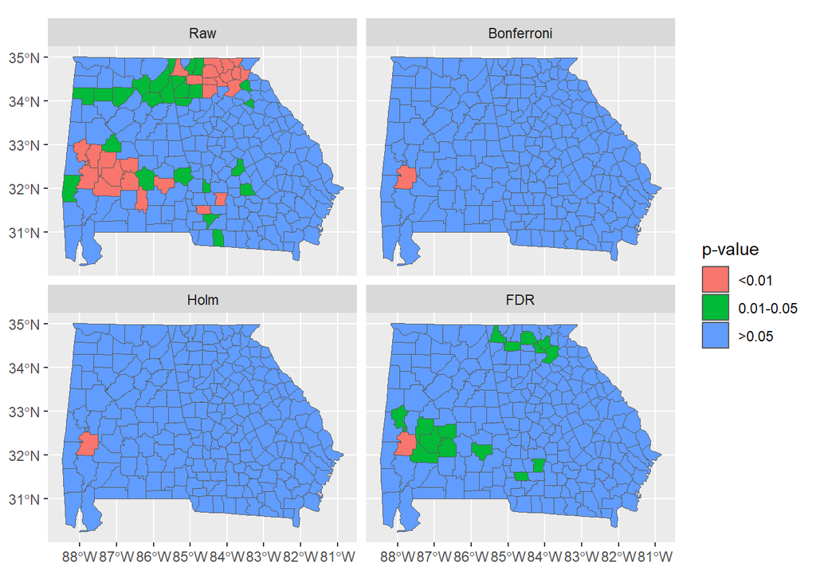

```r
dat.areal$I.local = I.local[,1]
I.local.p = I.local[,5]
I.local.p_bonf = p.adjust (I.local[,5], method ="bonferroni")
I.local.p_holm = p.adjust (I.local[,5], method ="holm")
I.local.p_fdr = p.adjust (I.local[,5], method ="fdr")

plot.dat = data.frame (FIPS = dat.areal$FIPS,
                  type =rep(c("Raw", "Bonferroni", "Holm", "FDR"), each = length (I.local.p)),
                  p = c(I.local.p, I.local.p_bonf, I.local.p_holm, I.local.p_fdr))
plot.dat$p=as.factor(cut(plot.dat$p, c(0,0.01, 0.05, 1), right=TRUE ))
levels (plot.dat$p) = c("<0.01", "0.01-0.05", ">0.05")
plot.dat$type = factor(plot.dat$type, levels = c("Raw", "Bonferroni", "Holm", "FDR"))

plot.dat = merge (dat.areal, plot.dat, by = "FIPS")
ggplot () + geom_sf (data = plot.dat, aes (fill = p)) + facet_wrap(~type)+
  scale_fill_discrete(name = "p-value")
```

```r
#Number of permutation
n.iter = 10000

#Row = 226 counties, column = permutation
I.keep = matrix (NA, ncol = n.iter, nrow = length (Y))
Y = dat.areal$inc

for (i in 1:n.iter){
  if (i %% 1000 ==0){print (i)}
  I.keep[,i] <- localmoran (sample (Y, length(Y), replace=T), col.W)[,1]
}
```

```
## [1] 1000
## [1] 2000
## [1] 3000
## [1] 4000
## [1] 5000
## [1] 6000
## [1] 7000
## [1] 8000
## [1] 9000
## [1] 10000
```

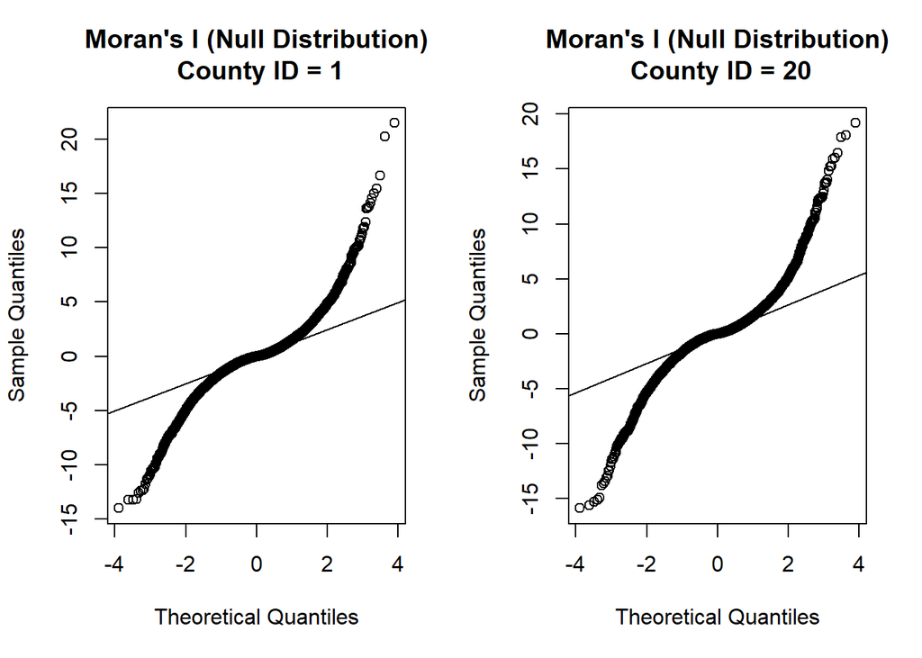

```r
#Check the normality for local Moran's I for county 1 and county 20
par (mfrow = c(1,2))
qqnorm(I.keep[1,], main = "Moran's I (Null Distribution)\n County ID = 1");qqline(I.keep[1,])
qqnorm(I.keep[20,], main = "Moran's I (Null Distribution)\n County ID = 20");qqline(I.keep[20,])
```

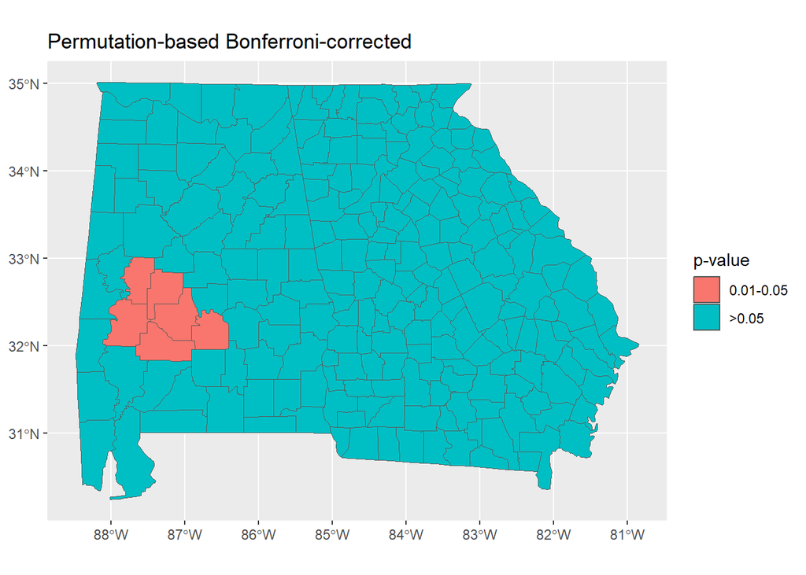

```r
I.obs = localmoran (Y, col.W)[,1]

#Calculate P(Local Moran's I > observed | Null)
P_perm = apply ( sweep (I.keep, 1, I.obs, ">" ), 1, mean)
P_perm[P_perm==0] = 1/n.iter

dat.areal$MoranI_perm_p= cut(p.adjust(P_perm, "bonferroni"), c(0,0.01, 0.05, 1) )
levels (dat.areal$MoranI_perm_p) = c("<0.01", "0.01-0.05", ">0.05")

ggplot () + geom_sf (data = dat.areal, aes (fill = MoranI_perm_p)) +
  ggtitle("Permutation-based Bonferroni-corrected") + scale_fill_discrete(name = "p-value")
```

# 3.5 Global Model-Based Cluster Detection

We will now focus on performing cluster detection specifically for case incidence data. We will use functions in the R package *DCluster*. These functions often require the input as a dataset with two variable names: Observed and Expected. First, we perform tests to see if spatial clustering exists.

```r
library (DCluster)
dismap = data.frame (Observed = dat.areal$Cases, Pop = dat.areal$Population)
theta_0 = sum(dismap$Observed)/sum(dismap$Pop)
dismap$Expected = dismap$Pop * theta_0

################
#   Chi2 test  #
################
#Asymptotic test
achisq.stat (dismap)
```

```
## $T
## [1] 21755.29
##
## $df
## [1] 225
##
## $pvalue
## [1] 0
```

```r
#Simulation-based
achisq.test(Observed~offset(log(Expected)), data = dismap, model = "poisson", R=1000)
```

```
## Chi-square test for overdispersion
##
##  Type of boots.: parametric
##  Model used when sampling: Poisson
##  Number of simulations: 1000
##  Statistic:  21755.29
##  p-value :  0.000999001
```

```r
achisq.test(Observed~offset(log(Expected)), data = dismap, model = "multinom", R=1000)
```

```
## Chi-square test for overdispersion
##
##  Type of boots.: parametric
##  Model used when sampling: Multinomial
##  Number of simulations: 1000
##  Statistic:  21755.29
##  p-value :  0.000999001
```

```r
achisq.test(Observed~offset(log(Expected)), data = dismap, model = "negbin", R=1000)
```

```
## Chi-square test for overdispersion
##
##  Type of boots.: parametric
##  Model used when sampling: Negative Binomial
##  Number of simulations: 1000
##  Statistic:  21755.29
##  p-value :  0.4055944
```

```r
##############################
# Potthoff-Whittinghill test #
##############################
pottwhitt.test(Observed~offset(log(Expected)), data = dismap, model = "poisson", R=1000)
```

```
## Potthoff-Whittinghill's test of overdispersion
##
##  Type of boots.: parametric
##  Model used when sampling: Poisson
##  Number of simulations: 1000
##  Statistic:  6032784494
##  p-value :  0.000999001
```

```r
pottwhitt.test(Observed~offset(log(Expected)), data = dismap, model = "multinom", R=1000)
```

```
## Potthoff-Whittinghill's test of overdispersion
##
##  Type of boots.: parametric
##  Model used when sampling: Multinomial
##  Number of simulations: 1000
##  Statistic:  6032784494
##  p-value :  0.000999001
```